None

# Start-up spending versus profit

### The data

|  | R&D Spend | Administration | Marketing Spend | State | Profit |
| --- | --- | --- | --- | --- | --- |
| 0 | 165349.20 | 136897.80 | 471784.10 | New York | 192261.83 |
| 1 | 162597.70 | 151377.59 | 443898.53 | California | 191792.06 |
| 2 | 153441.51 | 101145.55 | 407934.54 | Florida | 191050.39 |
| 3 | 144372.41 | 118671.85 | 383199.62 | New York | 182901.99 |
| 4 | 142107.34 | 91391.77 | 366168.42 | Florida | 166187.94 |

|  | R&D Spend | Administration | Marketing Spend | Profit |
| --- | --- | --- | --- | --- |
| count | 50.000000 | 50.000000 | 50.000000 | 50.000000 |
| mean | 73721.615600 | 121344.639600 | 211025.097800 | 112012.639200 |
| std | 45902.256482 | 28017.802755 | 122290.310726 | 40306.180338 |
| min | 0.000000 | 51283.140000 | 0.000000 | 14681.400000 |
| 25% | 39936.370000 | 103730.875000 | 129300.132500 | 90138.902500 |
| 50% | 73051.080000 | 122699.795000 | 212716.240000 | 107978.190000 |
| 75% | 101602.800000 | 144842.180000 | 299469.085000 | 139765.977500 |
| max | 165349.200000 | 182645.560000 | 471784.100000 | 192261.830000 |

### Amount of money spend on marketing versus profit

Since it is unclear if '0' marketing spend indead means the start-ups did not spend anything on marketing or that '0' was filled out when the number are unknown, I did not take them out.

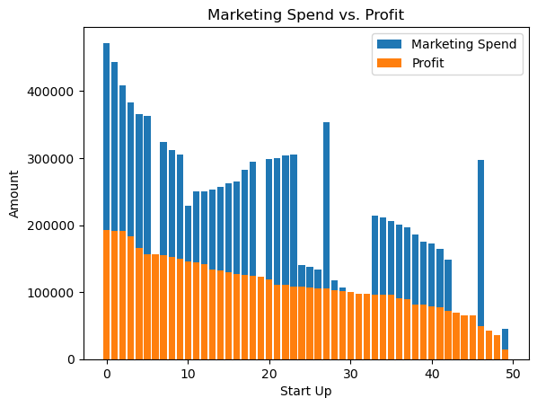

This scatter plot gives an overview of what cost start-ups the most compared to their profit.

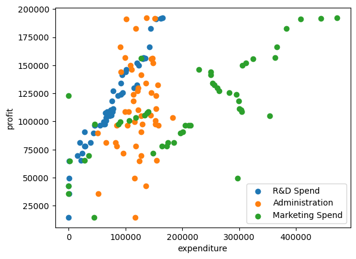

### This Heatmap shows the correlation between R&D Spend, Administration, Marketing Spend and Profit. The closer to '1' , the more they are correlated. For example: there is a high correlation between R&D spend and the profit that a start-up have made.

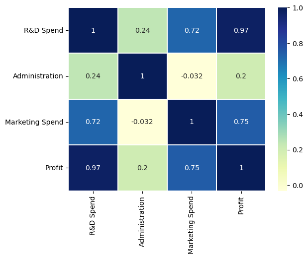

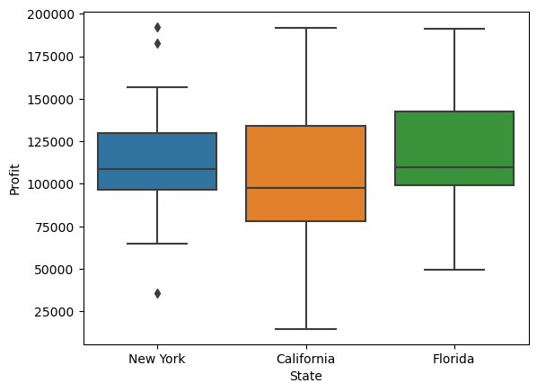

### The distribution of the profit made by the start-ups is normal

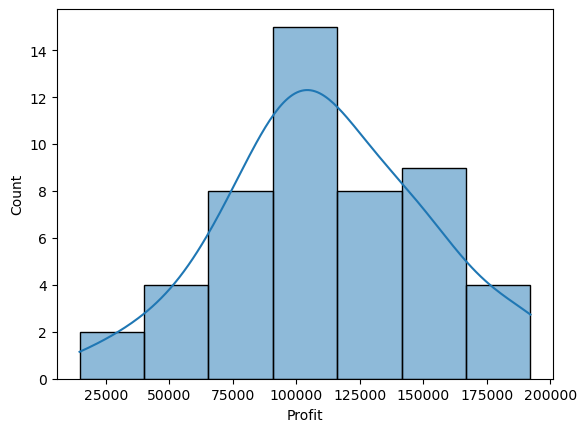

### These plots give an overview of the correlation between R&D spend, administration and marketing spend and profit. The impact of the R&D as well as marketing spend is positive for start-ups in all three states. The same can be said about expenditure for administration in New York, however, the impact of administration is moderate for the start-ups in Calafornia and even negative for the start-ups in Florida. This outcome can help future start-ups to reconsider that spending on administration.

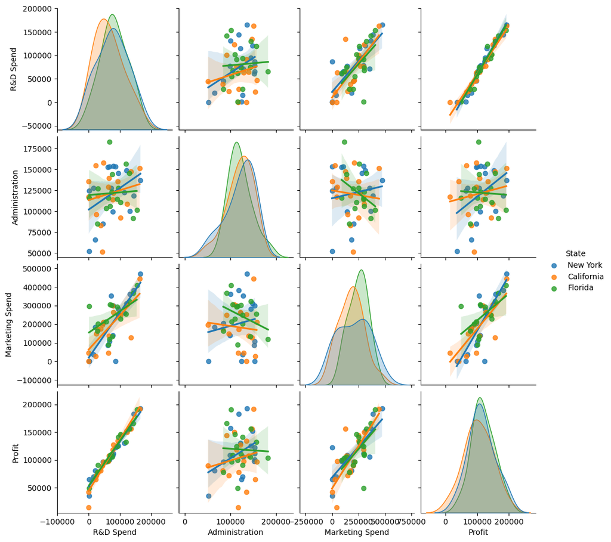

### I have trained a model to learn the relationship between the independent variables X_train (R&D spend, administration and marketing spend) the dependent variable y_train (profit). This knowledge helps to forecast if a start-up will be succesfull in terms of profit.This plot show that the actual values retrieved from the data and the predicted values lay very close to each other. This means the model was trained well and could be used to make predictions for new start-ups.

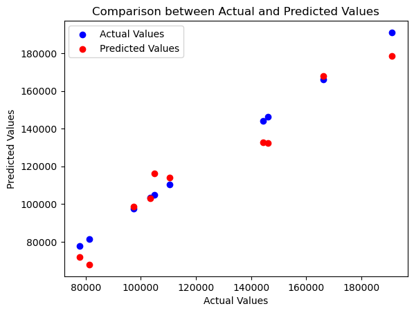